# Renal Clear Cell Carcinoma

Nick Borcherding

9/21/2018

Quick note: The clonotype information is difficult to work with and requires some assumptions. The first assumption was that we are selecting the TCR from A and B chains. The next assumption is simplifying the number of sequences down to the two top TCRA and TCRB hits, respectively.

# Set Up

```r
library(ggplot2)
library(reshape2)
library(dplyr)
library(circlize)
library(cowplot)
```

Loading the meta data from the RDSS drive clustering

```r
meta2 <- read.delim("~/Documents/GitHub/SC_Immune_Renal_Project/data/Renal_metaData.txt")
meta2$barcode <- rownames(meta2)
meta2$barcode  <- substr(meta2$barcode ,1,nchar(as.vector(meta2$barcode))-2)

newcluster <- read.delim("~/Documents/GitHub/SC_Immune_Renal_Project/data/Renal_newCLuster_ID.txt")
meta2 <- merge(meta2, newcluster, by="row.names")
```

Loading the contrigs and processing the cell barcode to match the meta data. I am also filtering the contigs to produce only data frames with productive contigs.

```r
P700 <- read.csv("~/Documents/GitHub/SC_Immune_Renal_Project/data/VDJ_GU0700/VDJ_GU0700_P/filtered_contig_annotations.csv")
P715 <- read.csv("~/Documents/GitHub/SC_Immune_Renal_Project/data/VDJ_GU0715/VDJ_GU0715_P/filtered_contig_annotations.csv")
P744 <- read.csv("~/Documents/GitHub/SC_Immune_Renal_Project/data/VDJ_GU0744/VDJ_GU0744_P/filtered_contig_annotations.csv")
T700 <- read.csv("~/Documents/GitHub/SC_Immune_Renal_Project/data/VDJ_GU0700/VDJ_GU0700_T/filtered_contig_annotations.csv")
T715 <- read.csv("~/Documents/GitHub/SC_Immune_Renal_Project/data/VDJ_GU0715/VDJ_GU0715_T/filtered_contig_annotations.csv")
T744 <- read.csv("~/Documents/GitHub/SC_Immune_Renal_Project/data/VDJ_GU0744/VDJ_GU0744_T/filtered_contig_annotations.csv")
```

```r
peripheral <- list(P700, P744, P715)
for (i in 1:length(peripheral)) {
  peripheral[[i]]$barcode <- paste("Patient", i, peripheral[[i]]$barcode, sep = "_")
  peripheral[[i]]$barcode <- substr(peripheral[[i]]$barcode,1,nchar(as.vector(peripheral[[i]]$barcode))-2)
  assign(noquote(paste("Peripheral_filtered", i, sep = "_")),  peripheral[[i]])
}

P700 <- subset(Peripheral_filtered_1, full_length =="True" & productive == "True" & chain != "Multi")
P715 <- subset(Peripheral_filtered_3, full_length =="True" & productive == "True" & chain != "Multi")
P744 <- subset(Peripheral_filtered_2, full_length =="True" & productive == "True" & chain != "Multi")

tumor <- list(T700, T744, T715)
for (i in 1:length(tumor)) {
  tumor[[i]]$barcode <- paste("Patient", i, tumor[[i]]$barcode, sep = "_")
  tumor[[i]]$barcode <- substr(tumor[[i]]$barcode,1,nchar(as.vector(tumor[[i]]$barcode))-2)
  assign(noquote(paste("Tumor_filtered", i, sep = "_")),  tumor[[i]])
}
T700 <- subset(Tumor_filtered_1, full_length =="True" & productive == "True" & chain != "Multi")
T715 <- subset(Tumor_filtered_3, full_length =="True" & productive == "True" & chain != "Multi")
T744 <- subset(Tumor_filtered_2, full_length =="True" & productive == "True" & chain != "Multi")
```

### Isolating TRA/TRB Contigs

We only want to look at TCR from the A and B chain, which is the vast majority of our clonotypes >97%

```r
ALL <- list(P700, P744, P715,T700, T744, T715)
names <- c("P700", "P744", "P715","T700", "T744", "T715")

for (i in 1:length(ALL)) {
  testTRB <- subset(ALL[[i]], chain =="TRB")
  testTRA <- subset(ALL[[i]], chain =="TRA")
  testTRB <- testTRB[!duplicated(testTRB$barcode),]
  testTRA <- testTRA[!duplicated(testTRA$barcode),]
  DF <- rbind(testTRA, testTRB)
  assign(noquote(paste(names[i], "Final_filtered", sep = "_")),  DF)
}

patient700 <- rbind(P700, T700)
patient700 <- merge(patient700, meta2, by = "barcode")
patient715 <- rbind(P715, T715)
patient715 <- merge(patient715, meta2, by = "barcode")
patient744 <- rbind(P744, T744)
patient744 <- merge(patient744, meta2, by.x = "barcode")
```

# Clonotype analysis by CD8 versus CD4 subtypes

### CD8 Isolation

Here the code condenses the clonotypes by frequency for both peripheral and tumor CD8 T cells.

```r
peripheral_names <- c("P700", "P744", "P715")

for (i in 1:length(peripheral)) {
  DF <- merge(peripheral[[i]], meta2, by = "barcode")
  DF <- subset(DF, CellType=="CD8")
  count <- DF[!duplicated(DF$barcode),]
  count <- as.data.frame(table(count$raw_clonotype_id))
  count <- subset(count, Freq > 0)
  count <- count %>%
    mutate(clonality = ifelse(Freq == 1, "One", ifelse(Freq == 2, "Two", "Greater3")))
  assign(noquote(paste(peripheral_names[i], "CD8clones", sep = "_")),  count)
}

tumor_names <- c("T700", "T744", "T715")
for (i in 1:length(tumor)) {
  DF2 <- merge(tumor[[i]], meta2, by = "barcode")
  DF2 <- subset(DF2, CellType=="CD8")
  count2 <- DF2[!duplicated(DF2$barcode),]
  count2 <- as.data.frame(table(count2$raw_clonotype_id))
  count2 <- subset(count2, Freq > 0)
  count2 <- count2 %>%
    mutate(clonality = ifelse(Freq == 1, "One", ifelse(Freq == 2, "Two", "Greater3")))
  assign(noquote(paste(tumor_names[i], "CD8clones", sep = "_")),  count2)

}
```

```r
for (i in 1:length(tumor)) {
  DF <- merge(tumor[[i]], meta2, by = "barcode")
  DF <- subset(DF, CellType=="CD8")
  count <- DF[!duplicated(DF$barcode),]
  count <- as.data.frame(table(count$raw_clonotype_id))
  count <- subset(count, Freq > 0)
  count <- count %>%
    mutate(clonality = ifelse(Freq == 1, "One", ifelse(Freq == 2, "Two", "Greater3")))
  assign(noquote(paste(tumor_names[i], "CD8clones", sep = "_")),  count)
}
```

Collapsing the data into a single table to graph

```r
pSum <- rbind.data.frame(table(P700_CD8clones$clonality), table(P715_CD8clones$clonality), table(P744_CD8clones$clonality))
colnames(pSum) <- c("Greater", "One", "Two")
rownames(pSum) <- c("p700", "p715", "p744")
pSum$type <- "PB"
pSum$Patient <- c("p700", "p715", "p744")

tSum <- rbind.data.frame(table(T700_CD8clones$clonality), table(T715_CD8clones$clonality), table(T744_CD8clones$clonality))
colnames(tSum) <- c("Greater", "One", "Two")
rownames(tSum) <- c("p700", "p715", "p744")
tSum$type <- "TM"
tSum$Patient <- c("p700", "p715", "p744")

totalSum <- rbind(pSum, tSum)
totalSum
```

```
##       Greater One Two type Patient
## p700       35 141  17   PB    p700
## p715       29  88  10   PB    p715
## p744       24  98  14   PB    p744
## p7001      74 363  41   TM    p700
## p7151      76 181  25   TM    p715
## p7441      79 283  55   TM    p744
```

Melting the data frame to graph

```r
melted <- melt(totalSum, id.vars = c("Patient", "type"))
melted$variable  <- factor(melted$variable, levels = c("Greater", "Two", "One"))
melted
```

```
##    Patient type variable value
## 1     p700   PB  Greater    35
## 2     p715   PB  Greater    29
## 3     p744   PB  Greater    24
## 4     p700   TM  Greater    74
## 5     p715   TM  Greater    76
## 6     p744   TM  Greater    79
## 7     p700   PB      One   141
## 8     p715   PB      One    88
## 9     p744   PB      One    98
## 10    p700   TM      One   363
## 11    p715   TM      One   181
## 12    p744   TM      One   283
## 13    p700   PB      Two    17
## 14    p715   PB      Two    10
## 15    p744   PB      Two    14
## 16    p700   TM      Two    41
## 17    p715   TM      Two    25
## 18    p744   TM      Two    55
```

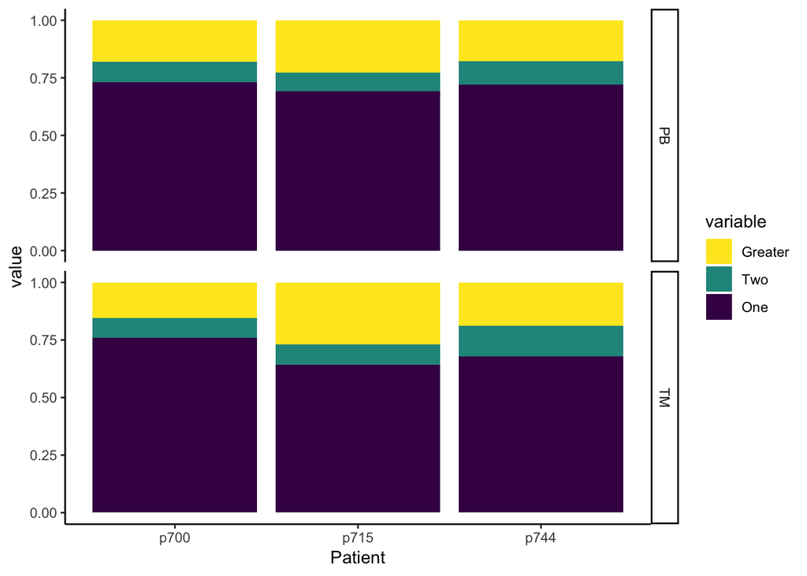

```r
ggplot(melted, aes(x=Patient, fill=variable, y=value)) +
  geom_bar(position = "fill", stat="identity") +
  facet_grid(type~.) +
  theme_classic()  +
   scale_fill_manual(values=c("#FDE723", "#22958B", "#430154"))
```

```r
ggsave("CD8_Clonotypes.pdf", width=3.5, height=3)
```

What is the change of clonotypes with >= 3 copies in CD8 T cellls?

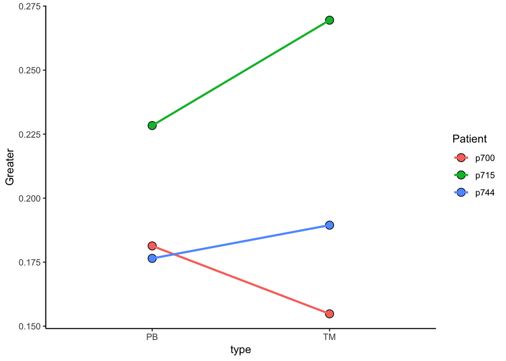

```r
change <- prop.table(t(totalSum[1:3]), margin=2)
change <- as.data.frame(t(change))
change <-change %>%
  mutate(clonal = Greater + Two)
change <- cbind(change, totalSum[,4:5])


ggplot(change, aes(x = type, y=Greater, group=Patient)) +
  geom_point(size=3.5, shape=21, aes(fill=Patient)) +
  geom_line(size=1, aes(color=Patient)) +
  theme(axis.title = element_blank())+
  theme_classic() +
  #guides(fill=F, color=F)
ggsave("Ajay_ClonalExpansion_n3_CD8.pdf", width=1.5, height=1.5)
```

```r
t.test(change$Greater ~ change$type)
```

```
##
##  Welch Two Sample t-test
##
## data:  change$Greater by change$type
## t = -0.24354, df = 2.8981, p-value = 0.8238
## alternative hypothesis: true difference in means is not equal to 0
## 95 percent confidence interval:
##  -0.1318477  0.1134480
## sample estimates:
## mean in group PB mean in group TM
##        0.1953881        0.2045879
```

What is the change of clonotypes = 2 copies in CD8 T cellls?

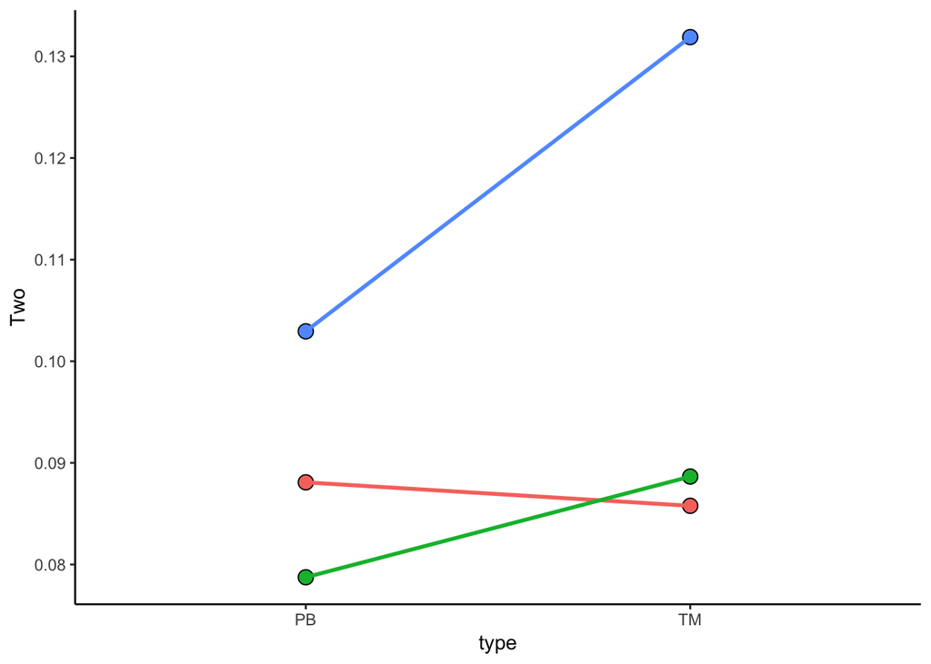

```r
ggplot(change, aes(x = type, y=Two, group=Patient)) +
  geom_point(size=3.5, shape=21, aes(fill=Patient)) +
  geom_line(size=1, aes(color=Patient)) +
  theme(axis.title = element_blank())+
  theme_classic() +
  guides(fill=F, color=F)
```

```r
ggsave("Ajay_ClonalExpansion_n2_CD8.pdf", width=1.5, height=1.5)
t.test(change$Two ~ change$type)
```

```
##
##  Welch Two Sample t-test
##
## data:  change$Two by change$type
## t = -0.73863, df = 2.8502, p-value = 0.5162
## alternative hypothesis: true difference in means is not equal to 0
## 95 percent confidence interval:
##  -0.06628357  0.04191238
## sample estimates:
## mean in group PB mean in group TM
##       0.08992141       0.10210701
```

### CD4 Isolation

Same as above, but subsetting based on CD4 cells

```r
peripheral_names <- c("P700", "P744", "P715")
tumor_names <- c("T700", "T744", "T715")
for (i in 1:length(peripheral)) {
  DF <- merge(peripheral[[i]], meta2, by = "barcode")
  DF <- subset(DF, CellType=="CD4")
  count <- DF[!duplicated(DF$barcode),]
  count <- as.data.frame(table(count$raw_clonotype_id))
  count <- subset(count, Freq > 0)
  count <- count %>%
    mutate(clonality = ifelse(Freq == 1, "One", ifelse(Freq == 2, "Two", "Greater3")))
  assign(noquote(paste(peripheral_names[i], "CD4clones", sep = "_")),  count)
}
for (i in 1:length(tumor)) {
  DF <- merge(tumor[[i]], meta2, by = "barcode")
  DF <- subset(DF, CellType=="CD4")
  count <- DF[!duplicated(DF$barcode),]
  count <- as.data.frame(table(count$raw_clonotype_id))
  count <- subset(count, Freq > 0)
  count <- count %>%
    mutate(clonality = ifelse(Freq == 1, "One", ifelse(Freq == 2, "Two", "Greater3")))
  assign(noquote(paste(tumor_names[i], "CD4clones", sep = "_")),  count)
}
```

Collapsing the data into a single table to graph

```r
pSum <- rbind.data.frame(table(P700_CD4clones$clonality), table(P715_CD4clones$clonality), table(P744_CD4clones$clonality))
colnames(pSum) <- c("Greater", "One", "Two")
rownames(pSum) <- c("p700", "p715", "p744")
pSum$type <- "PB"
pSum$Patient <- c("p700", "p715", "p744")

tSum <- rbind.data.frame(table(T700_CD4clones$clonality), table(T715_CD4clones$clonality), table(T744_CD4clones$clonality))
colnames(tSum) <- c("Greater", "One", "Two")
rownames(tSum) <- c("p700", "p715", "p744")
tSum$type <- "TM"
tSum$Patient <- c("p700", "p715", "p744")

totalSum <- rbind(pSum, tSum)
totalSum
```

```
##       Greater  One Two type Patient
## p700        3 2257  19   PB    p700
## p715       11  953  16   PB    p715
## p744        5  667  10   PB    p744
## p7001      26  683  34   TM    p700
## p7151      19  307  12   TM    p715
## p7441       9  336  20   TM    p744
```

```r
melted <- melt(totalSum, id.vars = c("Patient", "type"))
melted$variable  <- factor(melted$variable, levels = c("Greater", "Two", "One"))
melted
```

```
##    Patient type variable value
## 1     p700   PB  Greater     3
## 2     p715   PB  Greater    11
## 3     p744   PB  Greater     5
## 4     p700   TM  Greater    26
## 5     p715   TM  Greater    19
## 6     p744   TM  Greater     9
## 7     p700   PB      One  2257
## 8     p715   PB      One   953
## 9     p744   PB      One   667
## 10    p700   TM      One   683
## 11    p715   TM      One   307
## 12    p744   TM      One   336
## 13    p700   PB      Two    19
## 14    p715   PB      Two    16
## 15    p744   PB      Two    10
## 16    p700   TM      Two    34
## 17    p715   TM      Two    12
## 18    p744   TM      Two    20
```

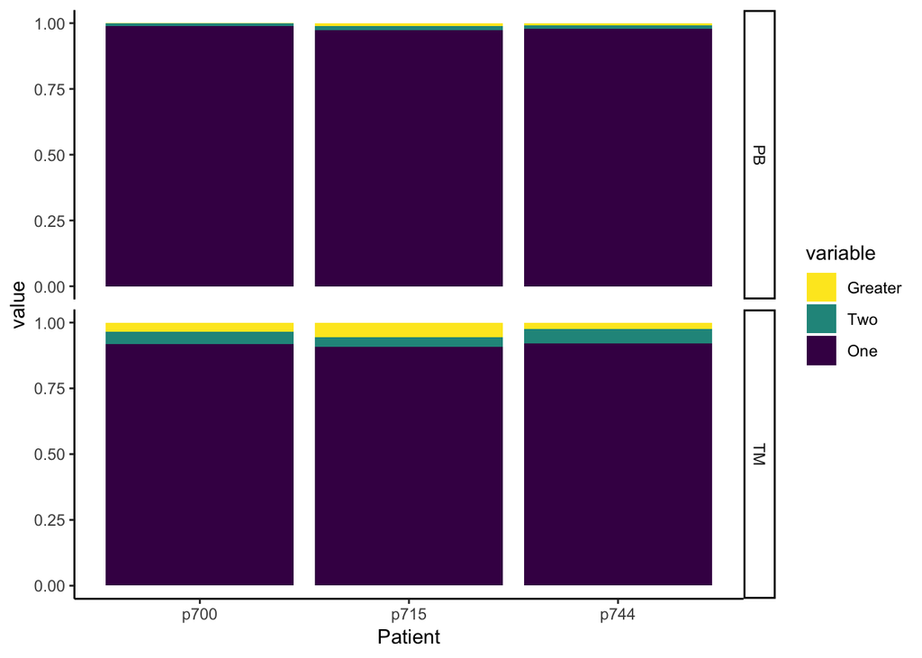

```r
ggplot(melted, aes(x=Patient, fill=variable, y=value)) +
  geom_bar(position = "fill", stat="identity") +
  facet_grid(type~.) +
  theme_classic()  +
   scale_fill_manual(values=c("#FDE723", "#22958B", "#430154"))
```

```r
ggsave("CD4_Clonotypes.pdf", width=3.5, height=3)
```

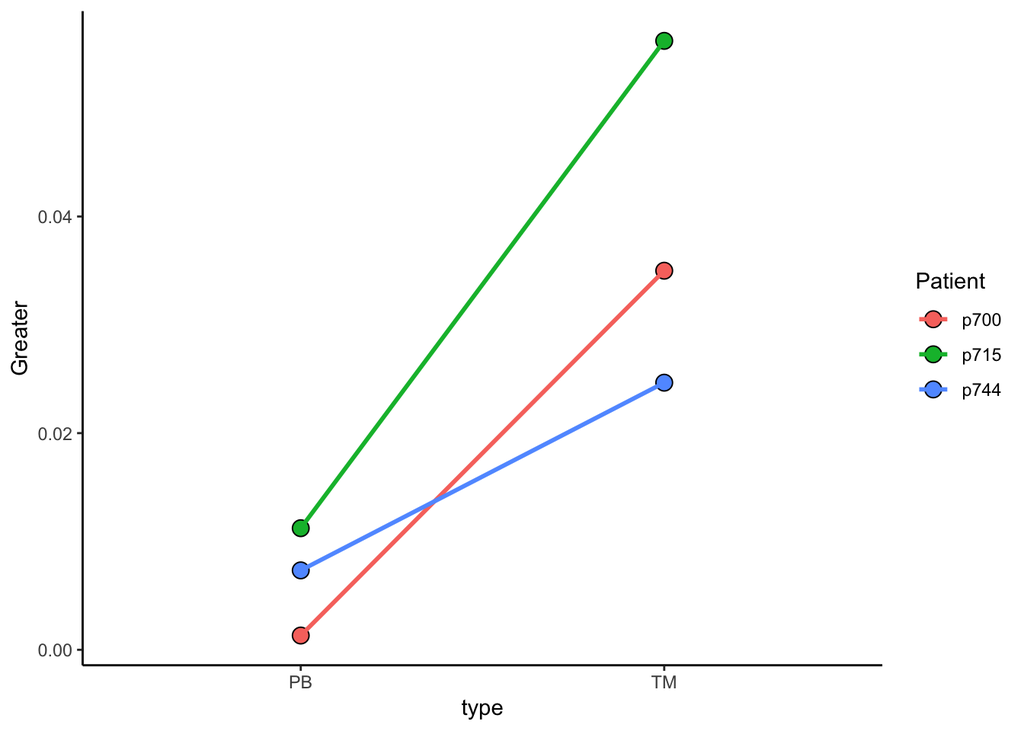

```r
change <- prop.table(t(totalSum[1:3]), margin=2)
change <- as.data.frame(t(change))
change <-change %>%
  mutate(clonal = Greater + Two)
change <- cbind(change, totalSum[,4:5])


ggplot(change, aes(x = type, y=Greater, group=Patient)) +
  geom_point(size=3.5, shape=21, aes(fill=Patient)) +
  geom_line(size=1, aes(color=Patient)) +
  theme(axis.title = element_blank())+
  theme_classic() +
  #guides(fill=F, color=F)
ggsave("Ajay_ClonalExpansion_n3_CD4.pdf", width=1.5, height=1.5)
```

```r
t.test(change$Greater ~ change$type)
```

```
##
##  Welch Two Sample t-test
##
## data:  change$Greater by change$type
## t = -3.2902, df = 2.3816, p-value = 0.06399
## alternative hypothesis: true difference in means is not equal to 0
## 95 percent confidence interval:
##  -0.068029177  0.004034785
## sample estimates:
## mean in group PB mean in group TM
##      0.006624078      0.038621274
```

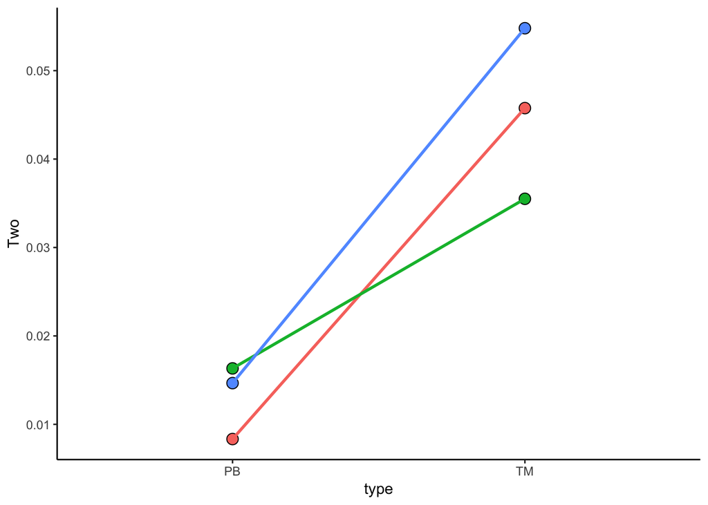

```r
ggplot(change, aes(x = type, y=Two, group=Patient)) +
  geom_point(size=3.5, shape=21, aes(fill=Patient)) +
  geom_line(size=1, aes(color=Patient)) +
  theme(axis.title = element_blank())+
  theme_classic() +
  guides(fill=F, color=F)
```

```r
ggsave("Ajay_ClonalExpansion_n2_CD4.pdf", width=1.5, height=1.5)
t.test(change$Two ~ change$type)
```

```
##
##  Welch Two Sample t-test
##
## data:  change$Two by change$type
## t = -5.3024, df = 2.7361, p-value = 0.01647
## alternative hypothesis: true difference in means is not equal to 0
## 95 percent confidence interval:
##  -0.05269615 -0.01179160
## sample estimates:
## mean in group PB mean in group TM
##       0.01310876       0.04535264
```

# Clonotype Analysis

Modify as needed for patient ID - this will calculate the poportion of clonotypes with 1, 2 or greater than 3 repeated instances in the same patient.

```r
#CD8
patients <- list(patient700, patient715, patient744)

for (i in 1:length(patients)) {
  dat <- patients[[i]]
  test <- subset(dat, data.ident == "0" | data.ident == "3" |data.ident== "6" |data.ident== "10" | data.ident == "17")
  test <- test[!duplicated(test$barcode),]

  z <- as.data.frame(table(test$raw_clonotype_id))
  z <- subset(z, Freq > 0)
  z <- z %>%
    mutate(clonality = ifelse(Freq == 1, "One", ifelse(Freq == 2, "Two", "Greater3")))
  test <- merge(test, z, by.x="raw_clonotype_id", by.y="Var1")
  assign(noquote(paste("outCD8", i, sep = "_")),  test)
}
```

```r
#CD4


for (i in 1:length(patients)) {
  dat <- patients[[i]]
  test <- subset(dat, data.ident == "1" | data.ident == "7" |data.ident== "12" | data.ident == "14" | data.ident == "21")
  test <- test[!duplicated(test$barcode),]

  z <- as.data.frame(table(test$raw_clonotype_id))
  z <- subset(z, Freq > 0)
  z <- z %>%
    mutate(clonality = ifelse(Freq == 1, "One", ifelse(Freq == 2, "Two", "Greater3")))
  test <- merge(test, z, by.x="raw_clonotype_id", by.y="Var1")
  assign(noquote(paste("outCD4", i, sep = "_")),  test)
}
```

Counting the CD8 clonotypes

```r
outputsCD8 <- list(outCD8_1, outCD8_2, outCD8_3)
outCD8 <- NULL

for (i in 1:length(outputsCD8 )) {
  dat <- outputsCD8[[i]]
  test <- dat[, c("raw_clonotype_id", "data.ident")]
  dTest <- dcast(test, raw_clonotype_id ~ data.ident)
  dTest <- dTest[apply(dTest[,-1], 1, function(x) !all(x==0)),]

    for (x in 2:6) {
      C0 <- length(which(dTest[,x] >= 1 & dTest[,2] >= 1))
      C3 <- length(which(dTest[,x] >= 1 & dTest[,3] >= 1))
      C6 <- length(which(dTest[,x] >= 1 & dTest[,4] >= 1))
      C10 <- length(which(dTest[,x] >= 1 & dTest[,5] >= 1))
      C17 <- length(which(dTest[,x] >= 1 & dTest[,6] >= 1))
      mat <- data.frame(C0, C3, C6, C10, C17)
      outCD8 <- rbind(outCD8,mat)
      assign(noquote(paste("outCD8_count", i, sep = "_")),  outCD8)
    }
  outCD8 <- NULL
}
```

Counting the CD4 clonotypes

```r
outputsCD4 <- list(outCD4_1, outCD4_2, outCD4_3)
outCD4 <- NULL


for (i in 1:length(outputsCD4)) {
  dat <- outputsCD4[[i]]
  test <- dat[, c("raw_clonotype_id", "data.ident")]
  dTest <- dcast(test, raw_clonotype_id ~ data.ident)
  dTest <- dTest[apply(dTest[,-1], 1, function(x) !all(x==0)),]

    for (x in 2:6) {
      C1 <- length(which(dTest[,x] >= 1 & dTest[,2] >= 1))
      C7 <- length(which(dTest[,x] >= 1 & dTest[,3] >= 1))
      C12 <- length(which(dTest[,x] >= 1 & dTest[,4] >= 1))
      C14 <- length(which(dTest[,x] >= 1 & dTest[,5] >= 1))
      C21 <- length(which(dTest[,x] >= 1 & dTest[,6] >= 1))
      mat <- data.frame(C1, C7, C12, C14, C21)
      outCD4 <- rbind(outCD4,mat)
      assign(noquote(paste("outCD4_count", i, sep = "_")),  outCD4)
    }
  outCD4 <- NULL
}
```

```r
countsCD4 <- list(outCD4_count_1, outCD4_count_2, outCD4_count_3)

for (i in 1:length(countsCD4)) {
  df <- countsCD4[[i]]
    for (x in 1:5) {
      df[x,x] <- df[x,x] - (colSums(df[x])-df[x,x])
      rownames(df) <- colnames(df)

    }
  assign(noquote(paste("outCD4_count_v2", i, sep = "_")),  df)
  df <- NULL
}
```

Subtracting the extra counts for CD8 data

```r
countsCD8 <- list(outCD8_count_1, outCD8_count_2, outCD8_count_3)

for (i in 1:length(countsCD8)) {
  df <- countsCD8[[i]]
    for (x in 1:5) {
      df[x,x] <- df[x,x] - (colSums(df[x])-df[x,x])
      rownames(df) <- colnames(df)
      if (df[5,5] < 0) {
        df[5,5] <- 0
      } else {
        df[5,5] <- df[5,5]
      }


    }
  assign(noquote(paste("outCD8_count_v2", i, sep = "_")),  df)
  df <- NULL
}
```

For looping to process CD8 clonotype information to find the mean

```r
df <- matrix(, nrow = 5, ncol = 5)
for (x in 1:5) {
  col1 <- c(prop.table(as.matrix(outCD8_count_v2_1), margin = 2)[x,1], prop.table(as.matrix(outCD8_count_v2_2), margin = 2)[x,1], prop.table(as.matrix(outCD8_count_v2_3), margin = 2)[x,1])
  col2 <- c(prop.table(as.matrix(outCD8_count_v2_1), margin = 2)[x,2], prop.table(as.matrix(outCD8_count_v2_2), margin = 2)[x,2], prop.table(as.matrix(outCD8_count_v2_3), margin = 2)[x,2])
  col3 <- c(prop.table(as.matrix(outCD8_count_v2_1), margin = 2)[x,3], prop.table(as.matrix(outCD8_count_v2_2), margin = 2)[x,3], prop.table(as.matrix(outCD8_count_v2_3), margin = 2)[x,3])
  col4 <- c(prop.table(as.matrix(outCD8_count_v2_1), margin = 2)[x,4], prop.table(as.matrix(outCD8_count_v2_2), margin = 2)[x,4], prop.table(as.matrix(outCD8_count_v2_3), margin = 2)[x,4])
  col5 <- c(prop.table(as.matrix(outCD8_count_v2_1), margin = 2)[x,5], prop.table(as.matrix(outCD8_count_v2_2), margin = 2)[x,5], prop.table(as.matrix(outCD8_count_v2_3), margin = 2)[x,5])
  df[x,1] <- mean(col1)
  df[x,2] <- mean(col2)
  df[x,3] <- mean(col3)
  df[x,4] <- mean(col4)
  df[x,5] <- mean(col5)
  assign("CD8mean",  df)
}
colnames(CD8mean) <- c("C0", "C3", "C6", "C10", "C17")
rownames(CD8mean) <- colnames(CD8mean)
```

For looping to process CD4 clonotype information to find the mean

```r
df <- matrix(, nrow = 5, ncol = 5)
for (x in 1:5) {
  col1 <- c(prop.table(as.matrix(outCD4_count_v2_1), margin = 2)[x,1], prop.table(as.matrix(outCD4_count_v2_2), margin = 2)[x,1], prop.table(as.matrix(outCD4_count_v2_3), margin = 2)[x,1])
  col2 <- c(prop.table(as.matrix(outCD4_count_v2_1), margin = 2)[x,2], prop.table(as.matrix(outCD4_count_v2_2), margin = 2)[x,2], prop.table(as.matrix(outCD4_count_v2_3), margin = 2)[x,2])
  col3 <- c(prop.table(as.matrix(outCD4_count_v2_1), margin = 2)[x,3], prop.table(as.matrix(outCD4_count_v2_2), margin = 2)[x,3], prop.table(as.matrix(outCD4_count_v2_3), margin = 2)[x,3])
  col4 <- c(prop.table(as.matrix(outCD4_count_v2_1), margin = 2)[x,4], prop.table(as.matrix(outCD4_count_v2_2), margin = 2)[x,4], prop.table(as.matrix(outCD4_count_v2_3), margin = 2)[x,4])
  col5 <- c(prop.table(as.matrix(outCD4_count_v2_1), margin = 2)[x,5], prop.table(as.matrix(outCD4_count_v2_2), margin = 2)[x,5], prop.table(as.matrix(outCD4_count_v2_3), margin = 2)[x,5])
  df[x,1] <- mean(col1)
  df[x,2] <- mean(col2)
  df[x,3] <- mean(col3)
  df[x,4] <- mean(col4)
  df[x,5] <- mean(col5)
  assign("CD4mean",  df)
}
colnames(CD4mean) <- c("C1", "C7", "C12", "C14", "C21")
rownames(CD4mean) <- colnames(CD4mean)
```

```r
CD4mean
```

```
##             C1         C7        C12        C14        C21
## C1  0.66841837 0.02895216 0.03248248 0.30785110 0.37835975
## C7  0.01504646 0.65396305 0.02047541 0.23303234 0.25369786
## C12 0.01250624 0.01157309 0.65118712 0.10174534 0.16375468
## C14 0.09723928 0.10982910 0.09718176 0.31637866 0.02481924
## C21 0.20678965 0.19568260 0.19867323 0.04099255 0.17936847
```

```r
write.table(CD4mean, file="Ajay_CD4clonotypes_average.txt", sep="\t",append=F)
write.table(outCD4_count_v2_1, file="Ajay_CD4clonotypes_Pt700.txt", sep="\t",append=F)
write.table(outCD4_count_v2_2, file="Ajay_CD4clonotypes_Pt715.txt", sep="\t",append=F)
write.table(outCD4_count_v2_3, file="Ajay_CD4clonotypes_Pt744.txt", sep="\t",append=F)
```

Mean contriubtion of clonotypes from CD4 clusters across all three patients

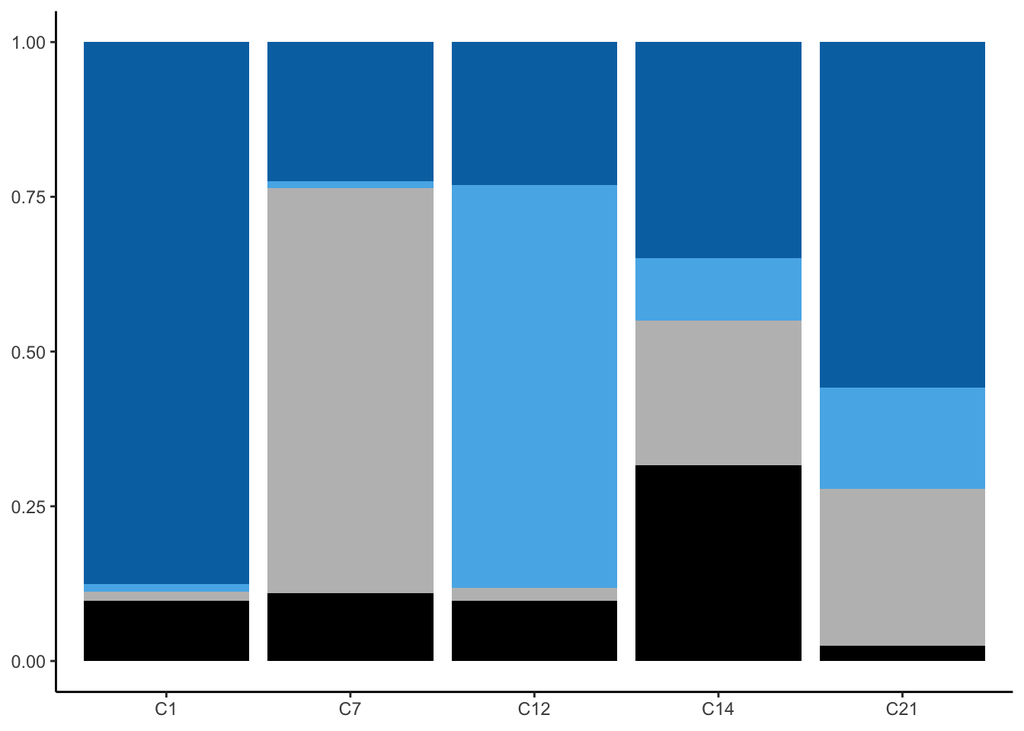

```r
meltCD4 <- melt(CD4mean)
meltCD4$Var1  <- factor(meltCD4$Var1, levels = c("C1", "C21", "C12", "C7", "C14"))
ggplot(meltCD4, aes(x=as.factor(Var2), y=value, fill=Var1)) +
  geom_bar(position = "fill", stat="identity") +
  scale_fill_manual(values = c("#0072B2","#0072B2", "#56B4E9", "#BEBEBE", "black")) +
  guides(fill=F) +
  theme_classic()  +
  theme(axis.title = element_blank())
```

```r
ggsave("AjayCD4_averageClusterclonotype.pdf", height=1, width=1.5)
```

```r
CD8mean
```

```
##             C0         C3        C6        C10        C17
## C0  0.44590686 0.12516627 0.2748337 0.09623294 0.35740347
## C3  0.10959740 0.50390597 0.2171620 0.23901053 0.12391547
## C6  0.24025776 0.18761106 0.1394516 0.34664158 0.32325022
## C10 0.07239945 0.12533901 0.2291942 0.26099707 0.09286673
## C17 0.13183852 0.05797769 0.1393585 0.05711788 0.10256410
```

```r
write.table(CD8mean, file="Ajay_CD8clonotypes_average.txt", sep="\t",append=F)
write.table(outCD8_count_v2_1, file="Ajay_CD8clonotypes_Pt700.txt", sep="\t",append=F)
write.table(outCD8_count_v2_2, file="Ajay_CD8clonotypes_Pt715.txt", sep="\t",append=F)
write.table(outCD8_count_v2_3, file="Ajay_CD8clonotypes_Pt744.txt", sep="\t",append=F)
```

Mean contriubtion of clonotypes from CD8 clusters across all three patients

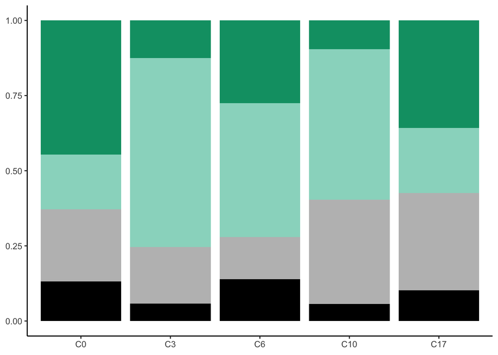

```r
meltCD8 <- melt(CD8mean)
meltCD8$Var1  <- factor(meltCD8$Var1, levels = c("C0", "C3", "C10", "C6", "C17"))
ggplot(meltCD8, aes(x=as.factor(Var2), y=value, fill=Var1)) +
  geom_bar(position = "fill", stat="identity") +
  scale_fill_manual(values = c("#009E73","#99D8C7", "#99D8C7", "#BEBEBE", "black")) +
guides(fill=F) +
  theme_classic()  +
  theme(axis.title = element_blank())
```

```r
ggsave("AjayCD8_averageClusterclonotype.pdf", height=1, width=1.5)
```

Prepping CD4 Data for Chord Diagrams

```r
list <- list(outCD4_count_v2_1, outCD4_count_v2_2, outCD4_count_v2_3)

for (x in 1:3) {
  df <- list[[x]]
  df[1,1] <- df[1,1]/2
  df[2,2] <- df[2,2]/2
  df[3,3] <- df[3,3]/2
  df[4,4] <- df[4,4]/2
  df[5,5] <- df[5,5]/2
  df <- as.matrix(df)
  df = data.frame(from = rep(rownames(df), times = ncol(df)),
    to = rep(colnames(df), each = nrow(df)),
    value = as.vector(df),
    stringsAsFactors = FALSE)
  df<- df[-c(4:6,8:10,14,15,24),]
  assign(noquote(paste("outCD4_chord", x, sep = "_")),  df)
}
```

Prepping CD8 Data for Chord Diagrams

```r
list <- list(outCD8_count_v2_1, outCD8_count_v2_2, outCD8_count_v2_3)

for (x in 1:3) {
  df <- list[[x]]
  df[1,1] <- df[1,1]/2
  df[2,2] <- df[2,2]/2
  df[3,3] <- df[3,3]/2
  df[4,4] <- df[4,4]/2
  df[5,5] <- df[5,5]/2
  df <- as.matrix(df)
  df = data.frame(from = rep(rownames(df), times = ncol(df)),
    to = rep(colnames(df), each = nrow(df)),
    value = as.vector(df),
    stringsAsFactors = FALSE)
  df<- df[-c(2,4,5,9,10,11:12,14:15, 20),]
  assign(noquote(paste("outCD8_chord", x, sep = "_")),  df)

}
```

CD4 Chord Diagrams, with patient GU0700 == X, GU0715 == Y, GU0744 == Z.

```r
grid.col = c(C1 = "#0072B2", C7= "#BEBEBE", C12="#56B4E9", C14= "black", C21="#0072B2")
pdf("CD4_CoordDiagrams.pdf", height=5, width=5)
X <- chordDiagram(outCD4_chord_1, grid.col = grid.col)
Y <- chordDiagram(outCD4_chord_2, grid.col = grid.col)
Z <- chordDiagram(outCD4_chord_3, grid.col = grid.col)
dev.off()
```

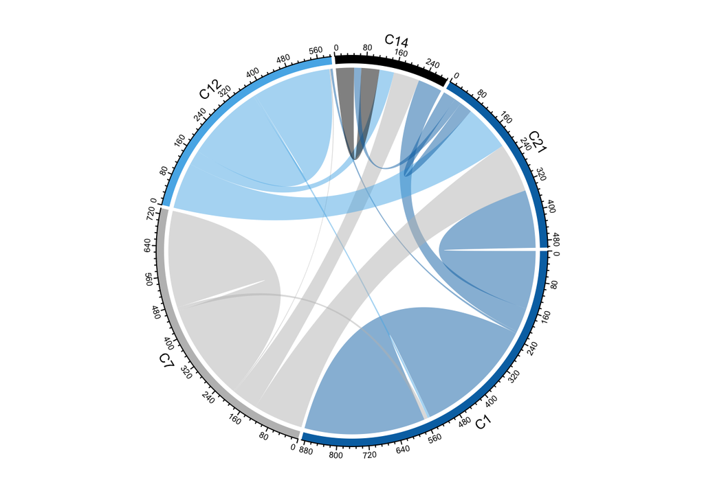

```r
chordDiagram(X, grid.col = grid.col)
```

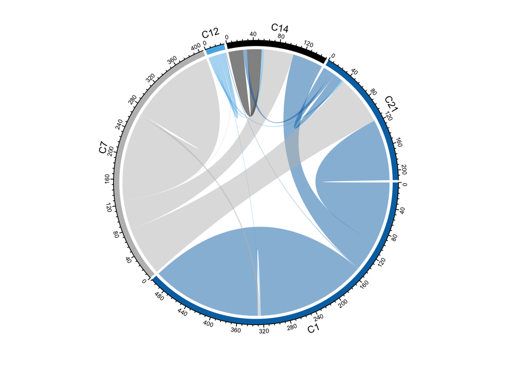

```r
chordDiagram(Y, grid.col = grid.col)
```

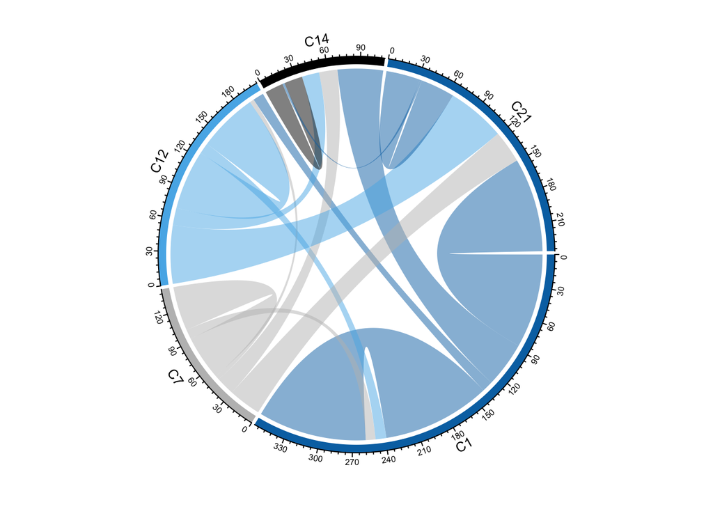

```r
chordDiagram(Z, grid.col = grid.col)
```

CD8 Chord Diagrams, with patient GU0700 == X, GU0715 == Y, GU0744 == Z.

```r
grid.col2 = c(C0 = "#009E73", C3= "#99D8C7", C6="#BEBEBE", C10= "#99D8C7", C17="black")
pdf("CD8_CoordDiagrams.pdf", height=5, width=5)
X <- chordDiagram(outCD8_chord_1, grid.col = grid.col2)
Y <- chordDiagram(outCD8_chord_2, grid.col = grid.col2)
Z <- chordDiagram(outCD8_chord_3, grid.col = grid.col2)
dev.off()
```

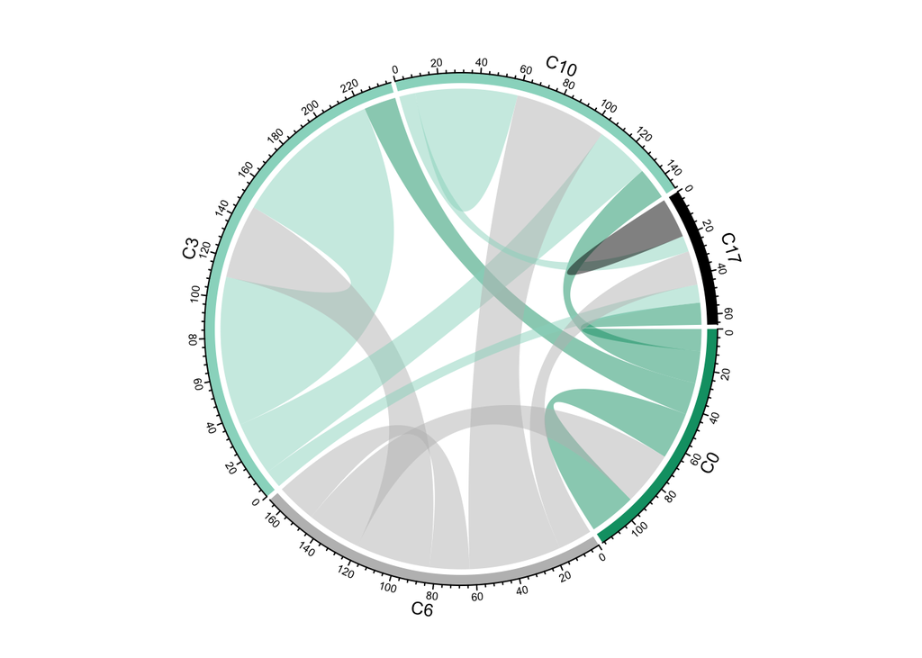

```r
chordDiagram(X, grid.col = grid.col2)
```

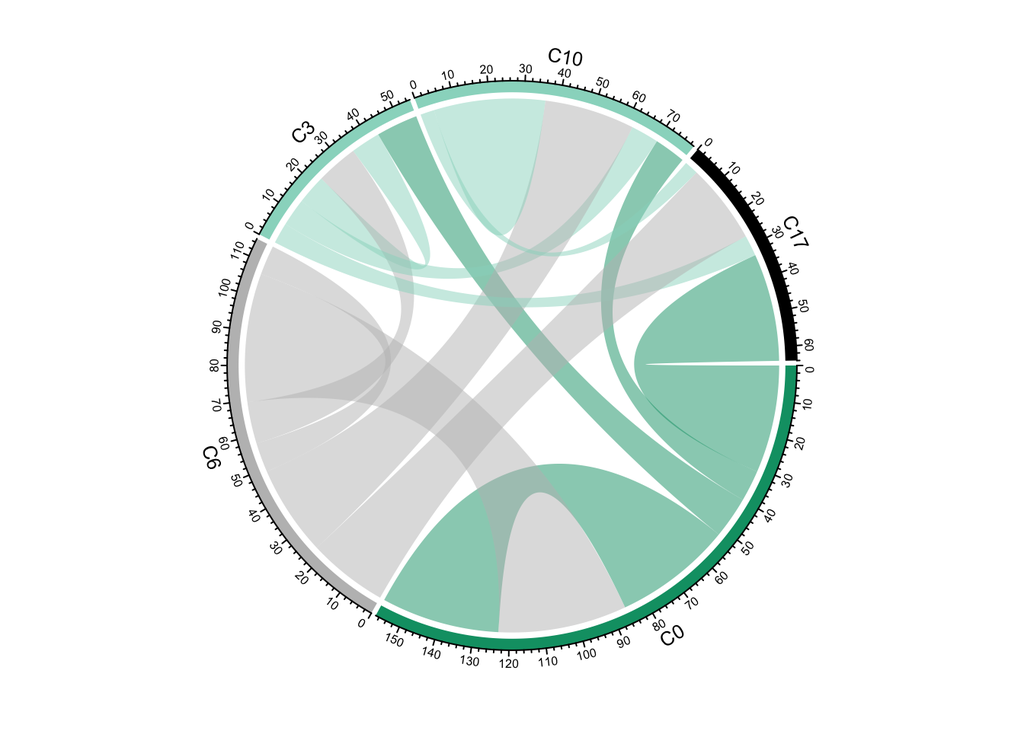

```r
chordDiagram(Y, grid.col = grid.col2)
```

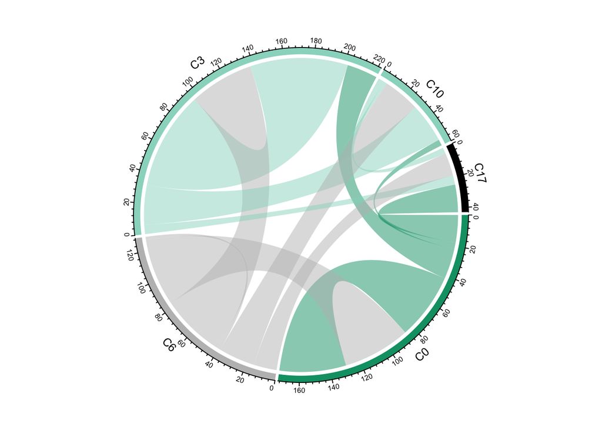

```r
chordDiagram(Z, grid.col = grid.col2)
```

# Top CDR3 Amino Acid Sequences

CD4 T Cluster 21

```r
Patients <- list(patient700, patient715, patient744)
Patients_names <- c("patient700", "patient715", "patient744")

for (i in 1:length(Patients)) {
  DF <- subset(Patients[[i]], data.ident==21)
  z <- as.data.frame(table(DF$raw_clonotype_id))
  test <- merge(DF, z, by.x="raw_clonotype_id", by.y="Var1")
  test <- test[order(test$Freq, decreasing = TRUE),]
  CDR3 <- head(unique(test$cdr3),3)
  Freq <- head(unique(test$Freq),3)
  count3 <- cbind.data.frame(CDR3, Freq)
  assign(noquote(paste(Patients_names[i], "Cluster21", sep = "_")),  count3)
}
```

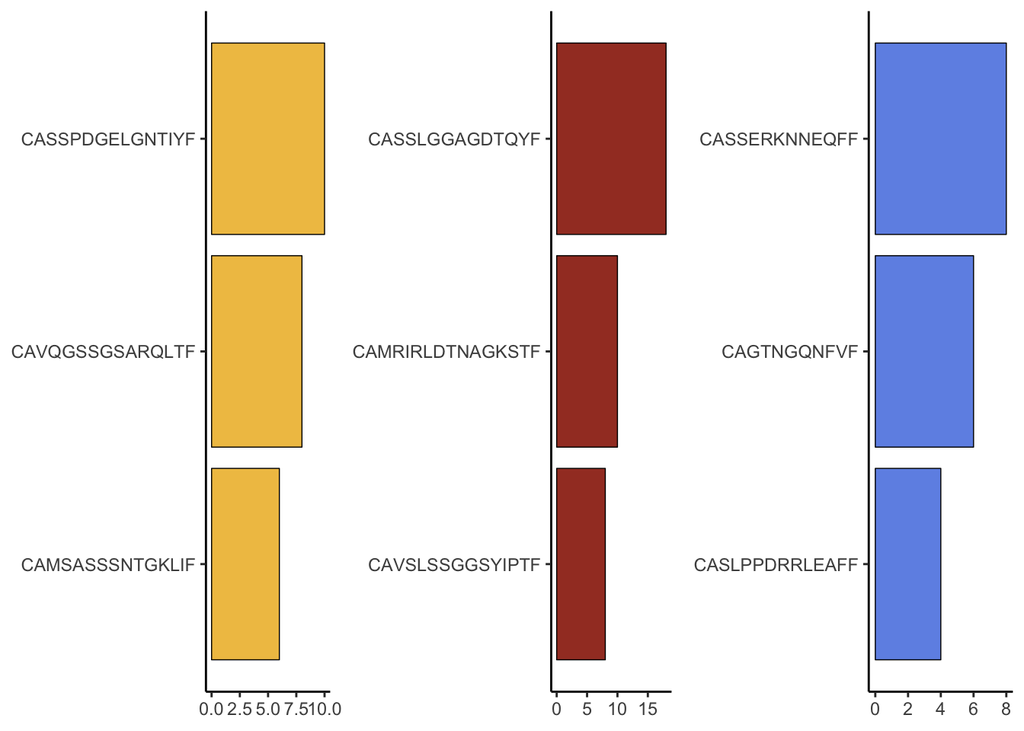

```r
X <-ggplot(patient700_Cluster21, aes(y=Freq, x=reorder(CDR3, Freq))) +
  geom_bar(stat="identity", fill="#F0C251", color="black", lwd=0.25) +
  coord_flip() +
  theme_classic()+
  theme(axis.title = element_blank())

Y <-ggplot(patient715_Cluster21, aes(y=Freq, x=reorder(CDR3, Freq))) +
  geom_bar(stat="identity", fill="#A43D2B", color="black", lwd=0.25) +
  coord_flip() +
  theme_classic() +
  theme(axis.title = element_blank())

Z <-ggplot(patient744_Cluster21, aes(y=Freq, x=reorder(CDR3, Freq))) +
  geom_bar(stat="identity", fill="#7093E6", color="black", lwd=0.25) +
  coord_flip() +
  theme_classic()+
  theme(axis.title = element_blank())

plot_grid(X,Y,Z, ncol=3)
```

```r
ggsave("CD4_Cluster21_Top3clonotypes.pdf", height=2.5, width=8)
```

Combined all CD4 PB cluster

```r
for (i in 1:length(Patients)) {
  DF <- subset(Patients[[i]], data.ident==1 | data.ident==7 | data.ident==12)
  z <- as.data.frame(table(DF$raw_clonotype_id))
  test <- merge(DF, z, by.x="raw_clonotype_id", by.y="Var1")
  test <- test[order(test$Freq, decreasing = TRUE),]
  CDR3 <- head(unique(test$cdr3),3)
  Freq <- head(unique(test$Freq),3)
  count3 <- cbind.data.frame(CDR3, Freq)
  assign(noquote(paste(Patients_names[i], "CD4PB", sep = "_")), count3)
}
```

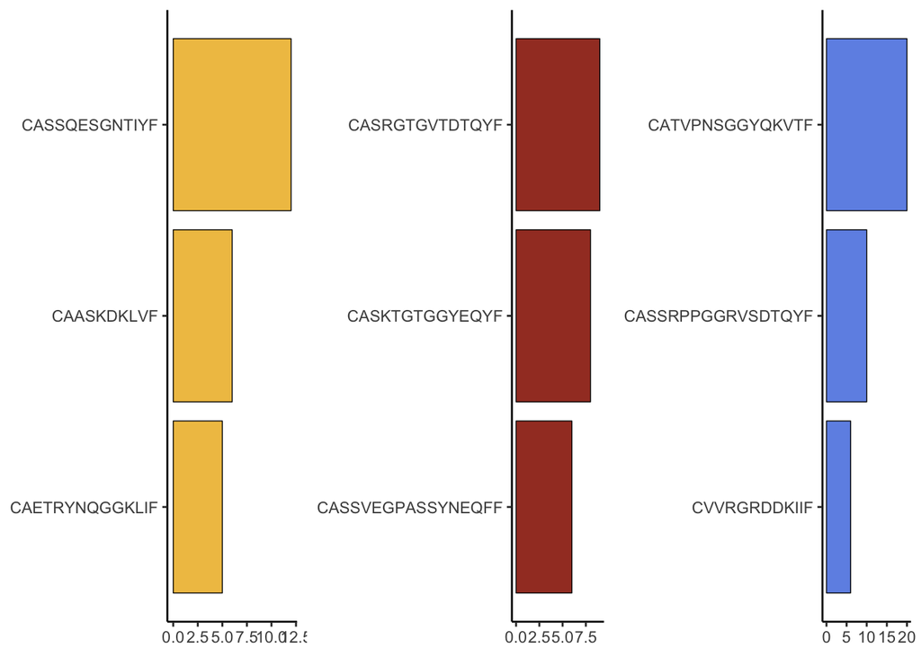

```r
X <-ggplot(patient700_CD4PB, aes(y=Freq, x=reorder(CDR3, Freq))) +
  geom_bar(stat="identity", fill="#F0C251", color="black", lwd=0.25) +
  coord_flip() +
  theme_classic()+
  theme(axis.title = element_blank())

Y <-ggplot(patient715_CD4PB, aes(y=Freq, x=reorder(CDR3, Freq))) +
  geom_bar(stat="identity", fill="#A43D2B", color="black", lwd=0.25) +
  coord_flip() +
  theme_classic() +
  theme(axis.title = element_blank())

Z <-ggplot(patient744_CD4PB, aes(y=Freq, x=reorder(CDR3, Freq))) +
  geom_bar(stat="identity", fill="#7093E6", color="black", lwd=0.25) +
  coord_flip() +
  theme_classic()+
  theme(axis.title = element_blank())

plot_grid(X,Y,Z, ncol=3)
```

```r
ggsave("CD4_PB_Top3clonotypes.pdf", height=2.5, width=8)
```

CD8 PB cluster

```r
for (i in 1:length(Patients)) {
  DF <- subset(Patients[[i]], data.ident==6)
  z <- as.data.frame(table(DF$raw_clonotype_id))
  test <- merge(DF, z, by.x="raw_clonotype_id", by.y="Var1")
  test <- test[order(test$Freq, decreasing = TRUE),]
  CDR3 <- head(unique(test$cdr3),3)
  Freq <- head(unique(test$Freq),3)
  count3 <- cbind.data.frame(CDR3, Freq)
  assign(noquote(paste(Patients_names[i], "CD8PB", sep = "_")),  count3)

}
```

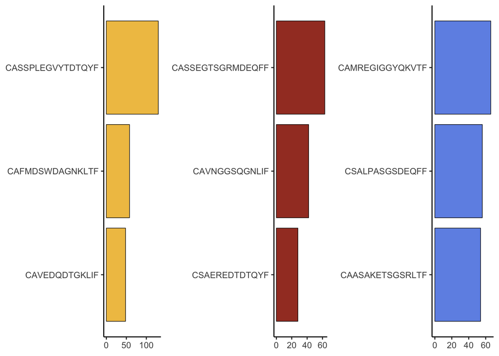

```r
X <-ggplot(patient700_CD8PB, aes(y=Freq, x=reorder(CDR3, Freq))) +
  geom_bar(stat="identity", fill="#F0C251", color="black", lwd=0.25) +
  coord_flip() +
  theme_classic()+
  theme(axis.title = element_blank())

Y <-ggplot(patient715_CD8PB, aes(y=Freq, x=reorder(CDR3, Freq))) +
  geom_bar(stat="identity", fill="#A43D2B", color="black", lwd=0.25) +
  coord_flip() +
  theme_classic() +
  theme(axis.title = element_blank())

Z <-ggplot(patient744_CD8PB, aes(y=Freq, x=reorder(CDR3, Freq))) +
  geom_bar(stat="identity", fill="#7093E6", color="black", lwd=0.25) +
  coord_flip() +
  theme_classic()+
  theme(axis.title = element_blank())

plot_grid(X,Y,Z, ncol=3)
```

```r
ggsave("CD8_PB_Top3clonotypes.pdf", height=2.5, width=8)
```

Combined all CD8 tumor cluster

```r
for (i in 1:length(Patients)) {
  DF <- subset(Patients[[i]], data.ident==0 | data.ident==3 | data.ident==10 | data.ident==17)
  z <- as.data.frame(table(DF$raw_clonotype_id))
  test <- merge(DF, z, by.x="raw_clonotype_id", by.y="Var1")
  test <- test[order(test$Freq, decreasing = TRUE),]
  CDR3 <- head(unique(test$cdr3),3)
  Freq <- head(unique(test$Freq),3)
  count3 <- cbind.data.frame(CDR3, Freq)
  assign(noquote(paste(Patients_names[i], "CD8TM", sep = "_")),  count3)
}
```

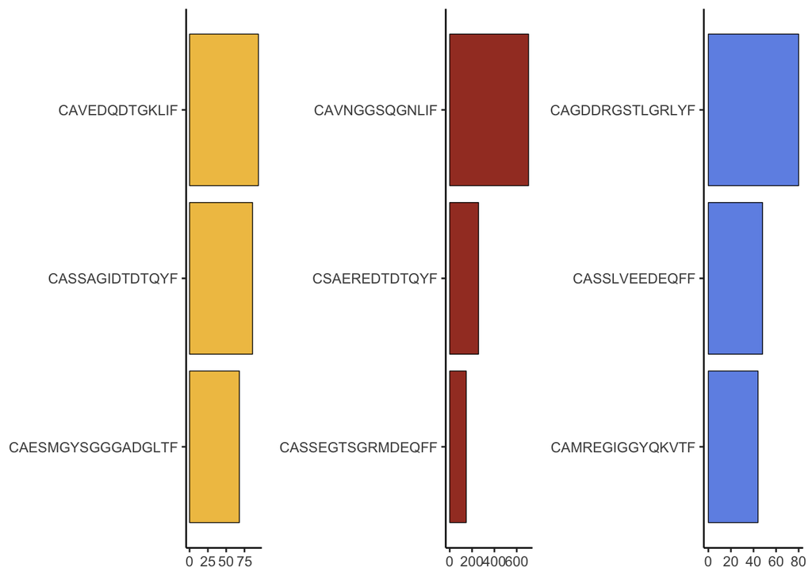

```r
X <-ggplot(patient700_CD8TM, aes(y=Freq, x=reorder(CDR3, Freq))) +
  geom_bar(stat="identity", fill="#F0C251", color="black", lwd=0.25) +
  coord_flip() +
  theme_classic()+
  theme(axis.title = element_blank())

Y <-ggplot(patient715_CD8TM, aes(y=Freq, x=reorder(CDR3, Freq))) +
  geom_bar(stat="identity", fill="#A43D2B", color="black", lwd=0.25) +
  coord_flip() +
  theme_classic() +
  theme(axis.title = element_blank())

Z <-ggplot(patient744_CD8TM, aes(y=Freq, x=reorder(CDR3, Freq))) +
  geom_bar(stat="identity", fill="#7093E6", color="black", lwd=0.25) +
  coord_flip() +
  theme_classic()+
  theme(axis.title = element_blank())

plot_grid(X,Y,Z, ncol=3)
```

```r
ggsave("CD8_tumor_Top3clonotypes.pdf", height=2.5, width=8)
```